# Assignment 6: GLMs (Linear Regressios, ANOVA, & t-tests)

Jiahuan Li

Spring 2023

## OVERVIEW

This exercise accompanies the lessons in Environmental Data Analytics on generalized linear models.

## Directions

1. Rename this file `<FirstLast>_A06_GLMs.Rmd` (replacing `<FirstLast>` with your first and last name).
2. Change “Student Name” on line 3 (above) with your name.
3. Work through the steps, **creating code and output** that fulfill each instruction.
4. Be sure to **answer the questions** in this assignment document.
5. When you have completed the assignment, **Knit** the text and code into a single PDF file.

## Set up your session

1. Set up your session. Check your working directory. Load the tidyverse, agricolae and other needed packages. Import the *raw* NTL-LTER raw data file for chemistry/physics (`NTL-LTER_Lake_ChemistryPhysics_Raw.csv`). Set date columns to date objects.
2. Build a ggplot theme and set it as your default theme.

```r
#1 load packages, vertify home directory, & import data
# install.packages("htmltools")
# install.packages("agricolae")
library(tidyverse)
library(lubridate)
library(here)
```

```r
library(agricolae)
library(ggthemes)
library(ggplot2)
here()
```

```
## [1] "C:/Users/jl1063/Documents/ENV872"
```

```r
lake <- read.csv (file = here(
  "Data/Raw/NTL-LTER_Lake_ChemistryPhysics_Raw.csv"))

lake$sampledate <- mdy(lake$sampledate)
str(lake$sampledate)
```

```
##  Date[1:38614], format: "1984-05-27" "1984-05-27" "1984-05-27" "1984-05-27" "1984-05-27" ...
```

```r
#2 Build a ggplot theme
my_theme <- theme_base() +
  theme(
    line = element_line(
      color='red',
      linewidth =2
    ),
    legend.background = element_rect(
      color='grey',
      fill = 'white'
    ),
    legend.title = element_text(
      color='black'
    ),
    plot.title = element_text(size = 10)
  )

theme_set(my_theme)
```

## Simple regression

Our first research question is: Does mean lake temperature recorded during July change with depth across all lakes?

> Answer:

> H0: The mean lake temperature recorded during July has nothing to do with the depth across all lakes.

> Ha: The mean lake temperature recorded during July changes with the depth across all lakes.
4. Wrangle your NTL-LTER dataset with a pipe function so that the records meet the following criteria:
- Only dates in July.
- Only the columns: `lakename`, `year4`, `daynum`, `depth`, `temperature_C`
- Only complete cases (i.e., remove NAs)
5. Visualize the relationship among the two continuous variables with a scatter plot of temperature by depth. Add a smoothed line showing the linear model, and limit temperature values from 0 to 35 °C. Make this plot look pretty and easy to read.

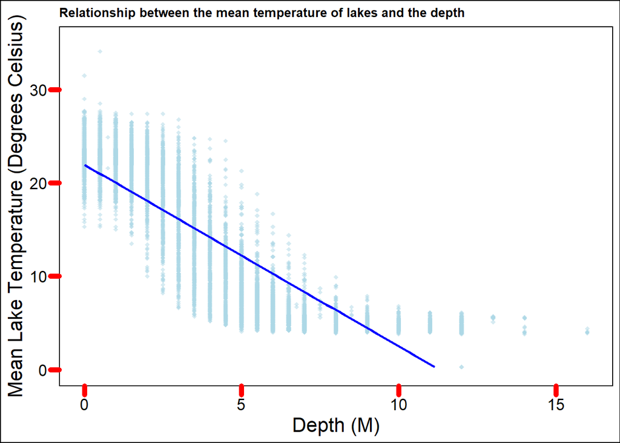

```r
#4
lake_July <-
  lake %>%
  filter(month(sampledate) == 7) %>%
  select(lakename, year4, daynum, depth, temperature_C) %>%
  na.omit()

#5
plot1 <- lake_July %>%
  ggplot(aes(x = depth, y = temperature_C)) +
  geom_point(colour = "lightblue", alpha = 0.5, shape = 18) +
  geom_smooth(method = "lm", col = "blue", se = F) +
  ylim(0,35) +
  xlab("Depth (M)") +
  ylab("Mean Lake Temperature (Degrees Celsius)") +
  ggtitle("Relationship between the mean temperature of lakes and the depth")

plot1
```

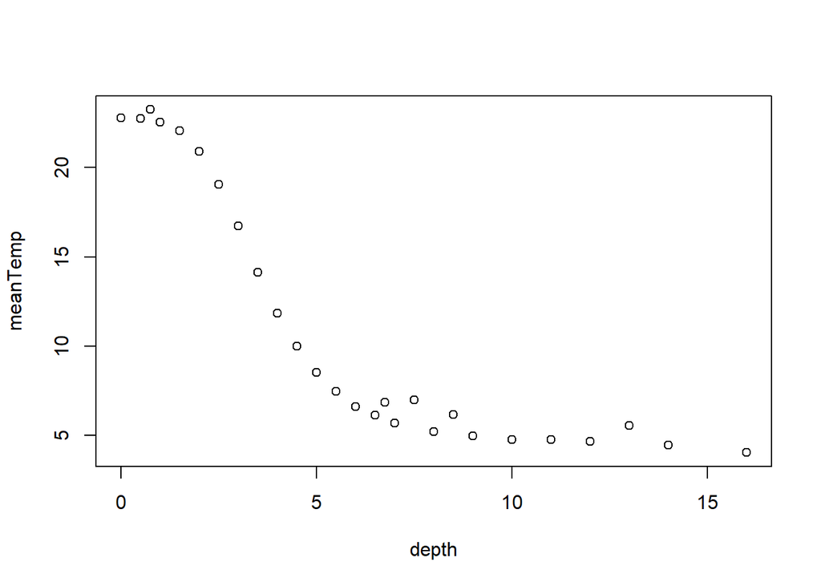

```r
# warning message is due to the limitation range of y

#6
lake_summarize <-
  lake_July %>%
  group_by(depth) %>%
  summarise(meanTemp = mean(temperature_C))
plot(lake_summarize)
```

6. Interpret the figure. What does it suggest with regards to the response of temperature to depth? Do the distribution of points suggest about anything about the linearity of this trend?

> Answer: The figure suggests that the mean temperature of lake negatively responds to the increase of depth. That is, the mean lake temperature at deeper location is lower than that of the higher ones when keeping other conditions the same. The negative relationship between the variables can be easily observed by examining the distribution of the scattered points. However, the distribution of the points alone does not necessarily indicate the linearity of the trend. Instead, it is more likely that the negative relation between the variables follows a logarithmic pattern. This is because the decrease in temperature appears to be less significant overall when it occurs over equal intervals of greater depth. The plot of the mean temperatures at each depth can briefly support this statement.
7. Perform a linear regression to test the relationship and display the results

```r
#7
lm1 <- lm(lake_July$temperature_C ~ lake_July$depth)
summary(lm1)
```

```
##
## Call:
## lm(formula = lake_July$temperature_C ~ lake_July$depth)
##
## Residuals:
##     Min      1Q  Median      3Q     Max
## -9.5173 -3.0192  0.0633  2.9365 13.5834
##
## Coefficients:
##                 Estimate Std. Error t value Pr(>|t|)
## (Intercept)     21.95597    0.06792   323.3   <2e-16 ***
## lake_July$depth -1.94621    0.01174  -165.8   <2e-16 ***
## ---
## Signif. codes:  0 '***' 0.001 '**' 0.01 '*' 0.05 '.' 0.1 ' ' 1
##
## Residual standard error: 3.835 on 9726 degrees of freedom
## Multiple R-squared:  0.7387, Adjusted R-squared:  0.7387
## F-statistic: 2.75e+04 on 1 and 9726 DF,  p-value: < 2.2e-16
```

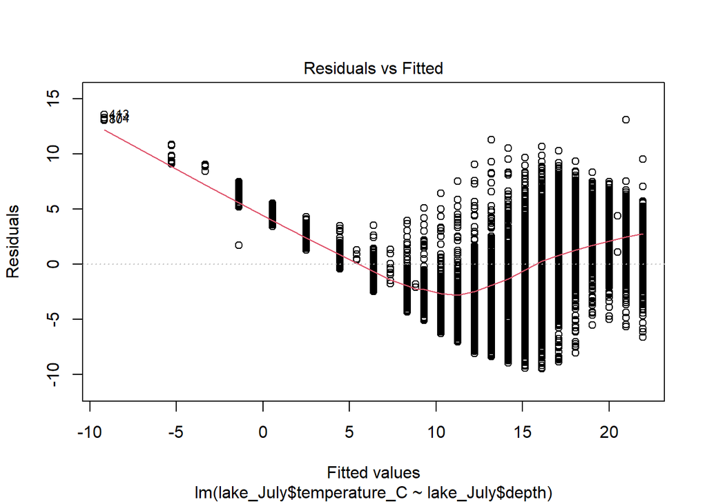

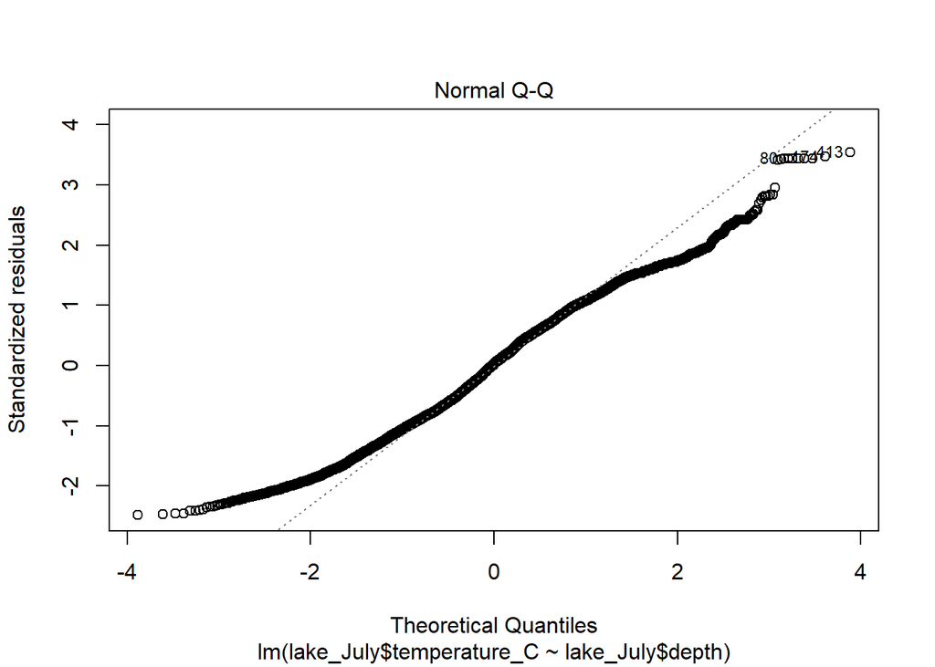

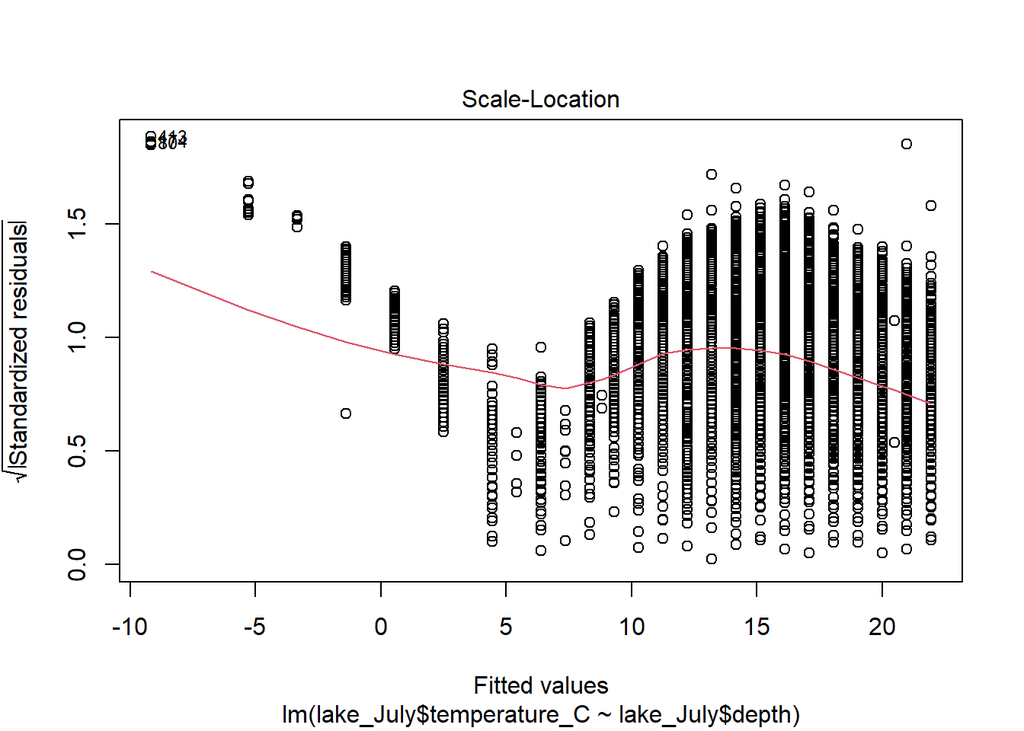

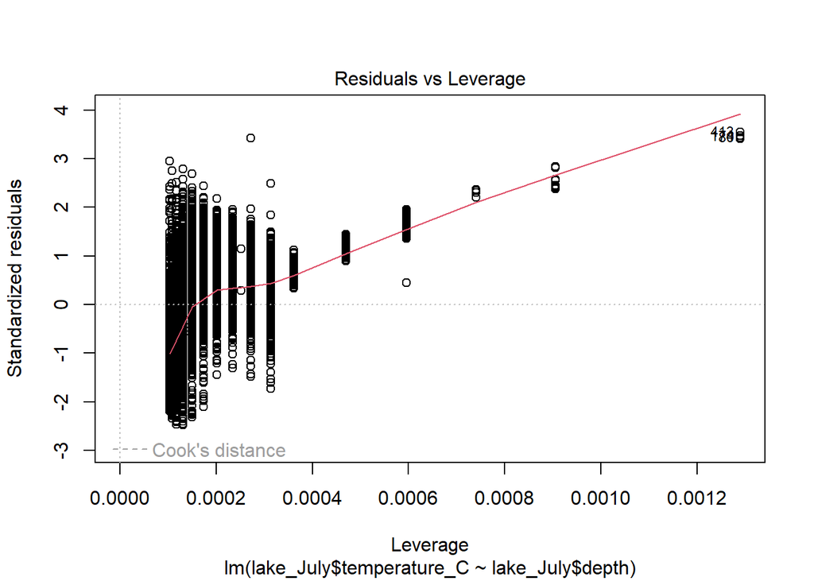

```r
plot(lm1)
```

8. Interpret your model results in words. Include how much of the variability in temperature is explained by changes in depth, the degrees of freedom on which this finding is based, and the statistical significance of the result. Also mention how much temperature is predicted to change for every 1m change in depth.

> Answer: According to the `Adjusted R-squared`, 73.87% of the variability in temperature is explained by changes in depth. This finding is based on 9726 degrees of freedom. The statistical significance of the result is indicated by p-value, which is less than 2.2e-16. The result indicates that, overall, the mean temperature of lakes will decrease 1.946 degree Celsius for every 1m increase in depth.

## Multiple regression

Let’s tackle a similar question from a different approach. Here, we want to explore what might the best set of predictors for lake temperature in July across the monitoring period at the North Temperate Lakes LTER.

9. Run an AIC to determine what set of explanatory variables (year4, daynum, depth) is best suited to predict temperature.
10. Run a multiple regression on the recommended set of variables.

```r
#9
AIC = lm(data= lake_July, temperature_C ~ year4 + daynum + depth)
step(AIC)
```

```
## Start:  AIC=26065.53
## temperature_C ~ year4 + daynum + depth
##
##          Df Sum of Sq    RSS   AIC
## <none>                141687 26066
## - year4   1       101 141788 26070
## - daynum  1      1237 142924 26148
## - depth   1    404475 546161 39189
```

```
##
## Call:
## lm(formula = temperature_C ~ year4 + daynum + depth, data = lake_July)
##
## Coefficients:
## (Intercept)        year4       daynum        depth
##    -8.57556      0.01134      0.03978     -1.94644
```

```r
# none of the variables can be removed.
# That is because if they are removed, the AIC number will increase

#10
Best = lm(data= lake_July, temperature_C ~ year4 + daynum + depth)
summary(Best)
```

```
##
## Call:
## lm(formula = temperature_C ~ year4 + daynum + depth, data = lake_July)
##
## Residuals:
##     Min      1Q  Median      3Q     Max
## -9.6536 -3.0000  0.0902  2.9658 13.6123
##
## Coefficients:
##              Estimate Std. Error  t value Pr(>|t|)
## (Intercept) -8.575564   8.630715   -0.994  0.32044
## year4        0.011345   0.004299    2.639  0.00833 **
## daynum       0.039780   0.004317    9.215  < 2e-16 ***
## depth       -1.946437   0.011683 -166.611  < 2e-16 ***
## ---
## Signif. codes:  0 '***' 0.001 '**' 0.01 '*' 0.05 '.' 0.1 ' ' 1
##
## Residual standard error: 3.817 on 9724 degrees of freedom
## Multiple R-squared:  0.7412, Adjusted R-squared:  0.7411
## F-statistic:  9283 on 3 and 9724 DF,  p-value: < 2.2e-16
```

11. What is the final set of explanatory variables that the AIC method suggests we use to predict temperature in our multiple regression? How much of the observed variance does this model explain? Is this an improvement over the model using only depth as the explanatory variable?

> Answer: The final set of explanatory variables suggested by the AIC method is a combination of `year4`, `daynum`, and `depth`. This model can explain 74.11% of the observed variance.

## Analysis of Variance

12. Now we want to see whether the different lakes have, on average, different temperatures in the month of July. Run an ANOVA test to complete this analysis. (No need to test assumptions of normality or similar variances.) Create two sets of models: one expressed as an ANOVA models and another expressed as a linear model (as done in our lessons).

```r
#12
# Format ANOVA as aov
lake.anova1 <- aov(data = lake_July, temperature_C ~ lakename)
summary(lake.anova1)
```

```
##               Df Sum Sq Mean Sq F value Pr(>F)
## lakename       8  21642  2705.2      50 <2e-16 ***
## Residuals   9719 525813    54.1
## ---
## Signif. codes:  0 '***' 0.001 '**' 0.01 '*' 0.05 '.' 0.1 ' ' 1
```

```r
# Format ANOVA as lm
lake.anova2 <- lm(data = lake_July, temperature_C ~ lakename)
summary(lake.anova2)
```

```
##
## Call:
## lm(formula = temperature_C ~ lakename, data = lake_July)
##
## Residuals:
##     Min      1Q  Median      3Q     Max
## -10.769  -6.614  -2.679   7.684  23.832
##
## Coefficients:
##                          Estimate Std. Error t value Pr(>|t|)
## (Intercept)               17.6664     0.6501  27.174  < 2e-16 ***
## lakenameCrampton Lake     -2.3145     0.7699  -3.006 0.002653 **
## lakenameEast Long Lake    -7.3987     0.6918 -10.695  < 2e-16 ***
## lakenameHummingbird Lake  -6.8931     0.9429  -7.311 2.87e-13 ***
## lakenamePaul Lake         -3.8522     0.6656  -5.788 7.36e-09 ***
## lakenamePeter Lake        -4.3501     0.6645  -6.547 6.17e-11 ***
## lakenameTuesday Lake      -6.5972     0.6769  -9.746  < 2e-16 ***
## lakenameWard Lake         -3.2078     0.9429  -3.402 0.000672 ***
## lakenameWest Long Lake    -6.0878     0.6895  -8.829  < 2e-16 ***
## ---
## Signif. codes:  0 '***' 0.001 '**' 0.01 '*' 0.05 '.' 0.1 ' ' 1
##
## Residual standard error: 7.355 on 9719 degrees of freedom
## Multiple R-squared:  0.03953,    Adjusted R-squared:  0.03874
## F-statistic:    50 on 8 and 9719 DF,  p-value: < 2.2e-16
```

13. Is there a significant difference in mean temperature among the lakes? Report your findings.

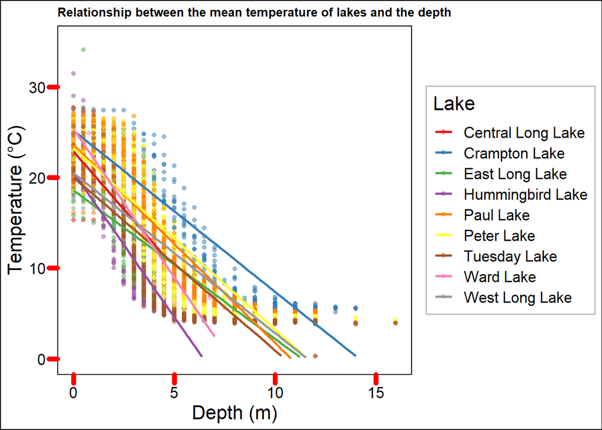

```r
#14.
plot2 <- lake_July %>%
  ggplot(aes(x = depth, y = temperature_C, color = lakename, group = lakename)) +
  geom_point(alpha = 0.5) +
  geom_smooth(method = "lm", se = F) +
  scale_color_brewer(palette = "Set1") +
  ylim(0,35) +
  labs(x = "Depth (m)", y = "Temperature (°C)", color = "Lake") +
  ggtitle("Relationship between the mean temperature of lakes and the depth")
plot2
```

15. Use the Tukey’s HSD test to determine which lakes have different means.

```r
#15
Tukey <- TukeyHSD(lake.anova1, ref = "Peter Lake")
Tukey
```

```
##   Tukey multiple comparisons of means
##     95% family-wise confidence level
##
## Fit: aov(formula = temperature_C ~ lakename, data = lake_July)
##
## $lakename
##                                          diff        lwr        upr     p adj
## Crampton Lake-Central Long Lake    -2.3145195 -4.7031913  0.0741524 0.0661566
## East Long Lake-Central Long Lake   -7.3987410 -9.5449411 -5.2525408 0.0000000
## Hummingbird Lake-Central Long Lake -6.8931304 -9.8184178 -3.9678430 0.0000000
## Paul Lake-Central Long Lake        -3.8521506 -5.9170942 -1.7872070 0.0000003
## Peter Lake-Central Long Lake       -4.3501458 -6.4115874 -2.2887042 0.0000000
## Tuesday Lake-Central Long Lake     -6.5971805 -8.6971605 -4.4972005 0.0000000
## Ward Lake-Central Long Lake        -3.2077856 -6.1330730 -0.2824982 0.0193405
## West Long Lake-Central Long Lake   -6.0877513 -8.2268550 -3.9486475 0.0000000
## East Long Lake-Crampton Lake       -5.0842215 -6.5591700 -3.6092730 0.0000000
## Hummingbird Lake-Crampton Lake     -4.5786109 -7.0538088 -2.1034131 0.0000004
## Paul Lake-Crampton Lake            -1.5376312 -2.8916215 -0.1836408 0.0127491
## Peter Lake-Crampton Lake           -2.0356263 -3.3842699 -0.6869828 0.0000999
## Tuesday Lake-Crampton Lake         -4.2826611 -5.6895065 -2.8758157 0.0000000
## Ward Lake-Crampton Lake            -0.8932661 -3.3684639  1.5819317 0.9714459
## West Long Lake-Crampton Lake       -3.7732318 -5.2378351 -2.3086285 0.0000000
## Hummingbird Lake-East Long Lake     0.5056106 -1.7364925  2.7477137 0.9988050
## Paul Lake-East Long Lake            3.5465903  2.6900206  4.4031601 0.0000000
## Peter Lake-East Long Lake           3.0485952  2.2005025  3.8966879 0.0000000
## Tuesday Lake-East Long Lake         0.8015604 -0.1363286  1.7394495 0.1657485
## Ward Lake-East Long Lake            4.1909554  1.9488523  6.4330585 0.0000002
## West Long Lake-East Long Lake       1.3109897  0.2885003  2.3334791 0.0022805
## Paul Lake-Hummingbird Lake          3.0409798  0.8765299  5.2054296 0.0004495
## Peter Lake-Hummingbird Lake         2.5429846  0.3818755  4.7040937 0.0080666
## Tuesday Lake-Hummingbird Lake       0.2959499 -1.9019508  2.4938505 0.9999752
## Ward Lake-Hummingbird Lake          3.6853448  0.6889874  6.6817022 0.0043297
## West Long Lake-Hummingbird Lake     0.8053791 -1.4299320  3.0406903 0.9717297
## Peter Lake-Paul Lake               -0.4979952 -1.1120620  0.1160717 0.2241586
## Tuesday Lake-Paul Lake             -2.7450299 -3.4781416 -2.0119182 0.0000000
## Ward Lake-Paul Lake                 0.6443651 -1.5200848  2.8088149 0.9916978
## West Long Lake-Paul Lake           -2.2356007 -3.0742314 -1.3969699 0.0000000
## Tuesday Lake-Peter Lake            -2.2470347 -2.9702236 -1.5238458 0.0000000
## Ward Lake-Peter Lake                1.1423602 -1.0187489  3.3034693 0.7827037
## West Long Lake-Peter Lake          -1.7376055 -2.5675759 -0.9076350 0.0000000
## Ward Lake-Tuesday Lake              3.3893950  1.1914943  5.5872956 0.0000609
## West Long Lake-Tuesday Lake         0.5094292 -0.4121051  1.4309636 0.7374387
## West Long Lake-Ward Lake           -2.8799657 -5.1152769 -0.6446546 0.0021080
```

```r
Lake.groups <- HSD.test(lake.anova1, "lakename", group = TRUE)
Lake.groups
```

```
## $statistics
##   MSerror   Df     Mean       CV
##   54.1016 9719 12.72087 57.82135
##
## $parameters
##    test   name.t ntr StudentizedRange alpha
##   Tukey lakename   9         4.387504  0.05
##
## $means
##                   temperature_C      std    r Min  Max    Q25   Q50    Q75
## Central Long Lake      17.66641 4.196292  128 8.9 26.8 14.400 18.40 21.000
## Crampton Lake          15.35189 7.244773  318 5.0 27.5  7.525 16.90 22.300
## East Long Lake         10.26767 6.766804  968 4.2 34.1  4.975  6.50 15.925
## Hummingbird Lake       10.77328 7.017845  116 4.0 31.5  5.200  7.00 15.625
## Paul Lake              13.81426 7.296928 2660 4.7 27.7  6.500 12.40 21.400
## Peter Lake             13.31626 7.669758 2872 4.0 27.0  5.600 11.40 21.500
## Tuesday Lake           11.06923 7.698687 1524 0.3 27.7  4.400  6.80 19.400
## Ward Lake              14.45862 7.409079  116 5.7 27.6  7.200 12.55 23.200
## West Long Lake         11.57865 6.980789 1026 4.0 25.7  5.400  8.00 18.800
##
## $comparison
## NULL
##
## $groups
##                   temperature_C groups
## Central Long Lake      17.66641      a
## Crampton Lake          15.35189     ab
## Ward Lake              14.45862     bc
## Paul Lake              13.81426      c
## Peter Lake             13.31626      c
## West Long Lake         11.57865      d
## Tuesday Lake           11.06923     de
## Hummingbird Lake       10.77328     de
## East Long Lake         10.26767      e
##
## attr(,"class")
## [1] "group"
```

16. From the findings above, which lakes have the same mean temperature, statistically speaking, as Peter Lake? Does any lake have a mean temperature that is statistically distinct from all the other lakes?

> Answer: Ward Lake and Paul Lake has the statistical same mean temperature as Peter Lake as shown in the `Lake.groups` as they have the same letter “c”. There is not a lake have a mean temperature that is statistically distinct from all the other lakes since their groups have joint letters.
17. If we were just looking at Peter Lake and Paul Lake. What’s another test we might explore to see whether they have distinct mean temperatures?

> Answer: The two-sample two-sided t-test can be adopted. It is designed to the situation with continuous response and one categorical explanatory variable with two categories.
18. Wrangle the July data to include only records for Crampton Lake and Ward Lake. Run the two-sample T-test on these data to determine whether their July temperature are same or different. What does the test say? Are the mean temperatures for the lakes equal? Does that match you answer for part 16?

```r
lake_t.test <- lake_July %>%
  filter(lakename == "Crampton Lake" | lakename == "Ward Lake")

# normality test
shapiro.test(lake_t.test$temperature_C[lake_t.test$lakename == "Crampton Lake"])
```

```
##
##  Shapiro-Wilk normality test
##
## data:  lake_t.test$temperature_C[lake_t.test$lakename == "Crampton Lake"]
## W = 0.89505, p-value = 5.194e-14
```

```r
shapiro.test(lake_t.test$temperature_C[lake_t.test$lakename == "Ward Lake"])
```

```
##
##  Shapiro-Wilk normality test
##
## data:  lake_t.test$temperature_C[lake_t.test$lakename == "Ward Lake"]
## W = 0.85654, p-value = 3.193e-09
```

```r
#in fact, the prerequisite is not satisfied since the null hypothesis is rejected.
#but method is robust from small deviations from normal distribution

# equal variance
bartlett.test(lake_t.test$temperature_C ~ lake_t.test$lakename)
```

```
##
##  Bartlett test of homogeneity of variances
##
## data:  lake_t.test$temperature_C by lake_t.test$lakename
## Bartlett's K-squared = 0.0852, df = 1, p-value = 0.7704
```

```r
# the null hypothesis that their variances are equal cannot be rejected.

# t-test
## note that the var.equal command is true here
lake.twosample <- t.test(lake_t.test$temperature_C ~ lake_t.test$lakename,
                         alternative = "two.sided",
                         var.equal = T)
lake.twosample
```

```
##
##  Two Sample t-test
##
## data:  lake_t.test$temperature_C by lake_t.test$lakename
## t = 1.1298, df = 432, p-value = 0.2592
## alternative hypothesis: true difference in means between group Crampton Lake and group Ward Lake is not equal to 0
## 95 percent confidence interval:
##  -0.660656  2.447188
## sample estimates:
## mean in group Crampton Lake     mean in group Ward Lake
##                    15.35189                    14.45862
```

> Answer: The July temperatures of Crampton Lake and Ward Lake are the same since the p-value for t-test is 0.2592, which indicates that the null-hypothesis, stating that the true difference in means between group Crampton Lake and group Ward Lake is equal to 0, cannot be rejected ($t$ = 1.1298, $df$ = 432, $p$ = 0.2592). It matches the answer for part 16 where the groups of both lakes contain the letter “b.”